# Analyzing U.S. Storm Data

Charles Westby

11/13/2017

# Synopsis

In this paper, we are going to look at storm data in the United States between the years 1950 and 2011. We will be trying to find, which types of weather event caused the most damage with regards to population health. We will track this damage by looking at how many injuries and fatalities each type of event caused. Next we will look at how much economic damage was caused by each type of weather event. At the end of the report we hope to know how we should allocate resources with regards to preparation for any coming weather events.

# Data Processing

Here I loaded the packages. Then I downloaded the file and created the variable Storm_data to hold the data as a data frame.

## Loading Libraries and Data

Here I loaded the packages. Then I downloaded the file and created the variable Storm_data to hold the data as a data frame.

```r
library(dplyr)
library(ggplot2)
library(gridExtra)

#Download, Read In and Store Data in a Data Frame
fileURL   <-  'https://d396qusza40orc.cloudfront.net/repdata%2Fdata%2FStormData.csv.bz2'
download.file(fileURL, destfile="StormData.csv.bz2", method = "curl")
storm_data    <-  read.csv("StormData.csv.bz2")
```

## Adding Crop Damage and Storm Damage Variables

Here I added the columns crop_damage and property_damage. This process was necessary because the columns PROPDMGEXP and CROPDMGEXP need to be combined with PROPDMG and CROPDMG in order to get a readable number. The former variables are exponents that need to be multiplied by the latter variables to get the accurate assessment of the damage.

```r
get_exponent <- function(exponent) {
exponent     <-  as.character(exponent)
exponent[toupper(exponent) == "H"]    <-  "2"
exponent[toupper(exponent) == "K"]    <-  "3"
exponent[toupper(exponent) == "M"]    <-  "6"
exponent[toupper(exponent) == "B"]    <-  "9"
exponent[is.na(exponent)]             <-  "0"
exponent     <-  as.numeric(exponent)
}

storm_data$PROPDMGEXP <- get_exponent(storm_data$PROPDMGEXP)
storm_data$CROPDMGEXP <- get_exponent(storm_data$CROPDMGEXP)

storm_data <- storm_data %>%
  mutate(property_damage = PROPDMG * 10^PROPDMGEXP,
         crop_damage = CROPDMG * 10^CROPDMGEXP)
```

## Changing Class of BGN_DATE Variable

Here I changed the class of the column BGN_DATE to a date class.

```r
#Change BGN_DATE column to a Date Class
storm_data$BGN_DATE <- as.Date(storm_data$BGN_DATE, "%m/%d/%Y %H:%M:%S")
```

# Results Population Health

## Top 20: Fatalities by Weather Event Types

Here I found out which types of weather event caused the most fatalities in the whole data set. Then I found out which types of weather event caused the most fatalities in the most recent twenty years in the data set.

```r
top_fatality <- storm_data %>%
  group_by(EVTYPE) %>% #Group by Event Type
  summarize(total_fatality = sum(FATALITIES)) %>% #Find total fatalities per event type
  arrange(desc(total_fatality)) %>% #Arrange in descending order
  head(20)
top_fatality #Print results
```

```
## Source: local data frame [20 x 2]
##
##                     EVTYPE total_fatality
##                     (fctr)          (dbl)
## 1                  TORNADO           5633
## 2           EXCESSIVE HEAT           1903
## 3              FLASH FLOOD            978
## 4                     HEAT            937
## 5                LIGHTNING            816
## 6                TSTM WIND            504
## 7                    FLOOD            470
## 8              RIP CURRENT            368
## 9                HIGH WIND            248
## 10               AVALANCHE            224
## 11            WINTER STORM            206
## 12            RIP CURRENTS            204
## 13               HEAT WAVE            172
## 14            EXTREME COLD            160
## 15       THUNDERSTORM WIND            133
## 16              HEAVY SNOW            127
## 17 EXTREME COLD/WIND CHILL            125
## 18             STRONG WIND            103
## 19                BLIZZARD            101
## 20               HIGH SURF            101
```

```r
#Perform same as previous chunk just filtering out everything before November 1991
top_fatality_20y <- storm_data %>%
  filter(BGN_DATE > "1991-11-01") %>%
  group_by(EVTYPE) %>%
  summarize(total_fatality = sum(FATALITIES)) %>%
  arrange(desc(total_fatality)) %>%
  head(20)
top_fatality_20y
```

```
## Source: local data frame [20 x 2]
##
##                     EVTYPE total_fatality
##                     (fctr)          (dbl)
## 1           EXCESSIVE HEAT           1903
## 2                  TORNADO           1662
## 3              FLASH FLOOD            978
## 4                     HEAT            937
## 5                LIGHTNING            816
## 6                    FLOOD            470
## 7              RIP CURRENT            368
## 8                TSTM WIND            255
## 9                HIGH WIND            248
## 10               AVALANCHE            224
## 11            WINTER STORM            206
## 12            RIP CURRENTS            204
## 13               HEAT WAVE            172
## 14            EXTREME COLD            160
## 15       THUNDERSTORM WIND            133
## 16              HEAVY SNOW            127
## 17 EXTREME COLD/WIND CHILL            125
## 18             STRONG WIND            103
## 19                BLIZZARD            101
## 20               HIGH SURF            101
```

## Top 20: Injury by Weather Event Types

Here I found which types of weather event caused the most injuries during the most recent twenty years and within the whole dataset.

```r
#Performing same process as earlier just for injuries
top_injury <- storm_data %>%
  group_by(EVTYPE) %>%
  summarize(total_injury = sum(INJURIES)) %>%
  arrange(desc(total_injury)) %>%
  head(20)
top_injury
```

```
## Source: local data frame [20 x 2]
##
##                EVTYPE total_injury
##                (fctr)        (dbl)
## 1             TORNADO        91346
## 2           TSTM WIND         6957
## 3               FLOOD         6789
## 4      EXCESSIVE HEAT         6525
## 5           LIGHTNING         5230
## 6                HEAT         2100
## 7           ICE STORM         1975
## 8         FLASH FLOOD         1777
## 9   THUNDERSTORM WIND         1488
## 10               HAIL         1361
## 11       WINTER STORM         1321
## 12  HURRICANE/TYPHOON         1275
## 13          HIGH WIND         1137
## 14         HEAVY SNOW         1021
## 15           WILDFIRE          911
## 16 THUNDERSTORM WINDS          908
## 17           BLIZZARD          805
## 18                FOG          734
## 19   WILD/FOREST FIRE          545
## 20         DUST STORM          440
```

```r
top_injury_20y <- storm_data %>%
  filter(BGN_DATE > "1991-11-01") %>%
  group_by(EVTYPE) %>%
  summarize(total_injury = sum(INJURIES)) %>%
  arrange(desc(total_injury)) %>%
  head(20)
top_injury_20y
```

```
## Source: local data frame [20 x 2]
##
##                EVTYPE total_injury
##                (fctr)        (dbl)
## 1             TORNADO        24739
## 2               FLOOD         6789
## 3      EXCESSIVE HEAT         6525
## 4           LIGHTNING         5230
## 5           TSTM WIND         3973
## 6                HEAT         2100
## 7           ICE STORM         1975
## 8         FLASH FLOOD         1777
## 9   THUNDERSTORM WIND         1488
## 10       WINTER STORM         1321
## 11  HURRICANE/TYPHOON         1275
## 12          HIGH WIND         1137
## 13               HAIL         1068
## 14         HEAVY SNOW         1021
## 15           WILDFIRE          911
## 16 THUNDERSTORM WINDS          908
## 17           BLIZZARD          805
## 18                FOG          734
## 19   WILD/FOREST FIRE          545
## 20         DUST STORM          440
```

## Graphs: Population Health

Here I graphed the findings of Top 20: Fatalities by Weather Event Type and Top 20: Injury by Weather Event Types.

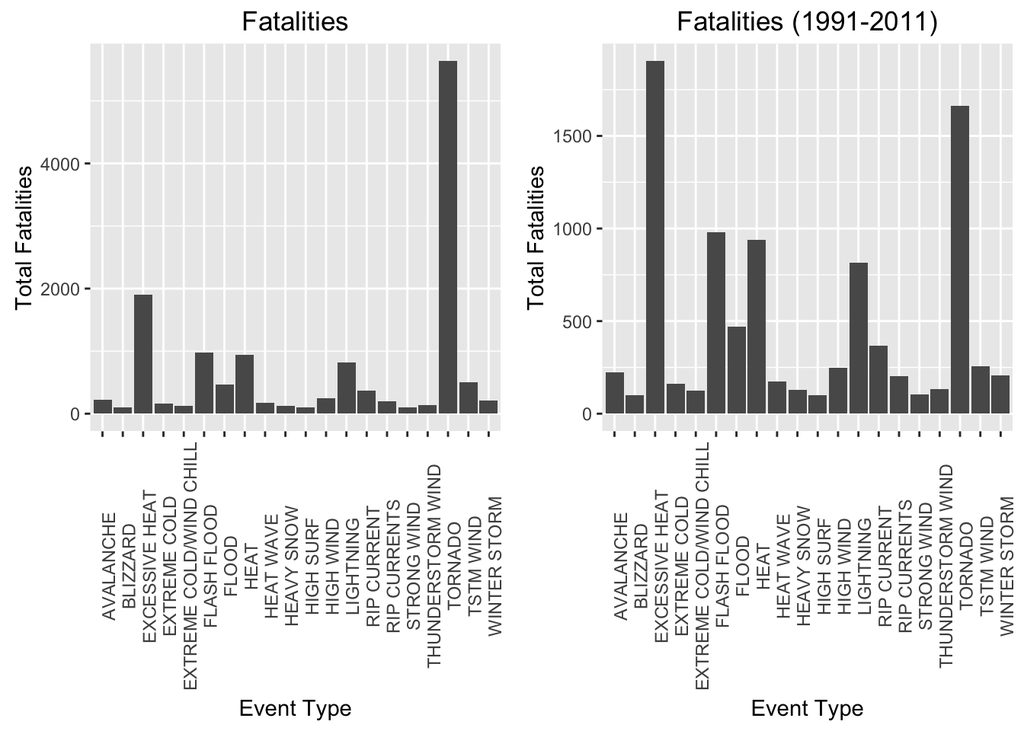

```r
fatality_graph <- ggplot(top_fatality, aes(x = EVTYPE, y =       total_fatality)) +
  geom_bar(stat = "identity") +
  theme(axis.text.x=element_text(angle=90)) +
  labs(x = "Event Type", y = "Total Fatalities", title = "Fatalities")

fatality_graph20 <- ggplot(top_fatality_20y, aes(x = EVTYPE,
  y = total_fatality)) + geom_bar(stat="identity") +
  theme(axis.text.x=element_text(angle=90)) +
  labs(x = "Event Type", y = "Total Fatalities", title = "Fatalities (1991-2011)")

injury_graph <- ggplot(top_injury, aes(x = EVTYPE, y = total_injury)) +
  geom_bar(stat = "identity") +
  theme(axis.text.x=element_text(angle=90)) +
  labs(x = "Event Type", y = "Total Injuries", title = "Injuries")


injury_graph20 <- ggplot(top_injury_20y, aes(x = EVTYPE,
  y = total_injury)) + geom_bar(stat="identity") +
  theme(axis.text.x=element_text(angle=90)) +
  labs(x = "Event Type", y = "Total Injuries", title = "Injuries (1991-2011)")

grid.arrange(fatality_graph, fatality_graph20, ncol=2)
```

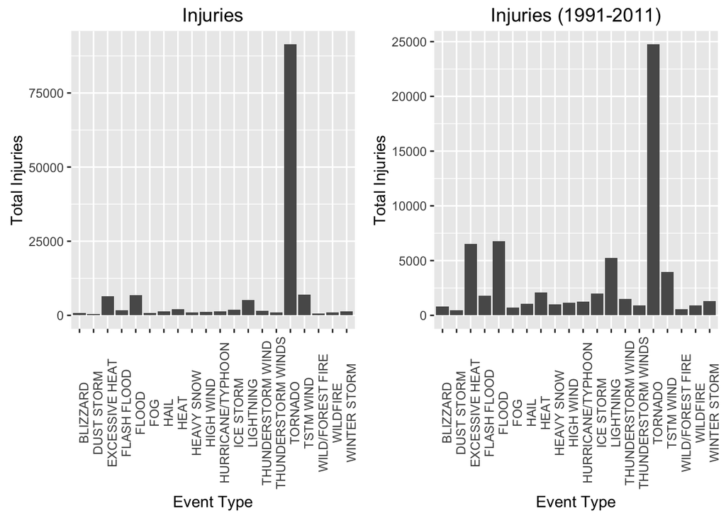

```r
grid.arrange(injury_graph, injury_graph20, ncol=2)
```

# Results Economic Damage

## Top 20: Crop Damage By Weather Event Type

Here I found the results of crop damage done for the whole data set and within the most recent 20 years of the data. There isn’t much difference between these two datasets. This suggests missing values from early in the dataset or better record keeping more recently

```r
top_crop <- storm_data %>%
  group_by(EVTYPE) %>%
  summarize(total_crop = sum(crop_damage)) %>%
  arrange(desc(total_crop)) %>%
  head(20)
top_crop
```

```
## Source: local data frame [20 x 2]
##
##                        EVTYPE total_crop
##                        (fctr)      (dbl)
## 1           EXCESSIVE WETNESS  142000000
## 2     COLD AND WET CONDITIONS   66000000
## 3                 Early Frost   42000000
## 4             Damaging Freeze   34130000
## 5                      Freeze   10500000
## 6   HURRICANE OPAL/HIGH WINDS   10000000
## 7             UNSEASONAL RAIN   10000000
## 8             HIGH WINDS/COLD    7000000
## 9           Unseasonable Cold    5100000
## 10               COOL AND WET    5000000
## 11    WINTER STORM HIGH WINDS    5000000
## 12 TORNADOES, TSTM WIND, HAIL    2500000
## 13       Heavy Rain/High Surf    1500000
## 14      DUST STORM/HIGH WINDS     500000
## 15               FOREST FIRES     500000
## 16      TROPICAL STORM GORDON     500000
## 17       FLASH FLOODING/FLOOD     175000
## 18               Frost/Freeze     100000
## 19                 HAIL/WINDS      50050
## 20          HEAT WAVE DROUGHT      50000
```

```r
top_crop_20y <- storm_data %>%
  filter(BGN_DATE > "1991-11-01") %>%
  group_by(EVTYPE) %>%
  summarize(total_crop = sum(crop_damage)) %>%
  arrange(desc(total_crop)) %>%
  head(20)
top_crop_20y
```

```
## Source: local data frame [20 x 2]
##
##                        EVTYPE total_crop
##                        (fctr)      (dbl)
## 1           EXCESSIVE WETNESS  142000000
## 2     COLD AND WET CONDITIONS   66000000
## 3                 Early Frost   42000000
## 4             Damaging Freeze   34130000
## 5                      Freeze   10500000
## 6   HURRICANE OPAL/HIGH WINDS   10000000
## 7             UNSEASONAL RAIN   10000000
## 8             HIGH WINDS/COLD    7000000
## 9           Unseasonable Cold    5100000
## 10               COOL AND WET    5000000
## 11    WINTER STORM HIGH WINDS    5000000
## 12 TORNADOES, TSTM WIND, HAIL    2500000
## 13       Heavy Rain/High Surf    1500000
## 14      DUST STORM/HIGH WINDS     500000
## 15               FOREST FIRES     500000
## 16      TROPICAL STORM GORDON     500000
## 17       FLASH FLOODING/FLOOD     175000
## 18               Frost/Freeze     100000
## 19                 HAIL/WINDS      50050
## 20          HEAT WAVE DROUGHT      50000
```

## Top 20: Property Damage by Weather Event Type

Here I found the results of property damaage done in the whole dataset and within the most recent 20 years of the data. Again we don’t see much change in the two datasets.

```r
top_prop <- storm_data %>%
  group_by(EVTYPE) %>%
  summarize(total_prop = sum(property_damage)) %>%
  arrange(desc(total_prop)) %>%
  head(20)
top_prop
```

```
## Source: local data frame [20 x 2]
##
##                           EVTYPE total_prop
##                           (fctr)      (dbl)
## 1     TORNADOES, TSTM WIND, HAIL 1600000000
## 2                     WILD FIRES  624100000
## 3                      HAILSTORM  241000000
## 4                HIGH WINDS/COLD  110500000
## 5                 River Flooding  106155000
## 6                    MAJOR FLOOD  105000000
## 7      HURRICANE OPAL/HIGH WINDS  100000000
## 8        WINTER STORM HIGH WINDS   60000000
## 9                HURRICANE EMILY   50000000
## 10            Erosion/Cstl Flood   16200000
## 11     COASTAL  FLOODING/EROSION   15000000
## 12          Heavy Rain/High Surf   13500000
## 13               LAKESHORE FLOOD    7540000
## 14        HIGH WINDS HEAVY RAINS    7500000
## 15                        FLOODS    6000000
## 16              ICE JAM FLOODING    5516000
## 17                  FOREST FIRES    5000000
## 18          HEAVY RAIN/LIGHTNING    5000000
## 19 HEAVY SNOW/BLIZZARD/AVALANCHE    5000000
## 20                HEAVY SNOWPACK    5000000
```

```r
top_prop_20y <- storm_data %>%
  filter(BGN_DATE > "1991-11-01") %>%
  group_by(EVTYPE) %>%
  summarize(total_prop = sum(property_damage)) %>%
  arrange(desc(total_prop)) %>%
  head(20)
top_prop_20y
```

```
## Source: local data frame [20 x 2]
##
##                           EVTYPE total_prop
##                           (fctr)      (dbl)
## 1     TORNADOES, TSTM WIND, HAIL 1600000000
## 2                     WILD FIRES  624100000
## 3                      HAILSTORM  241000000
## 4                HIGH WINDS/COLD  110500000
## 5                 River Flooding  106155000
## 6                    MAJOR FLOOD  105000000
## 7      HURRICANE OPAL/HIGH WINDS  100000000
## 8        WINTER STORM HIGH WINDS   60000000
## 9                HURRICANE EMILY   50000000
## 10            Erosion/Cstl Flood   16200000
## 11     COASTAL  FLOODING/EROSION   15000000
## 12          Heavy Rain/High Surf   13500000
## 13               LAKESHORE FLOOD    7540000
## 14        HIGH WINDS HEAVY RAINS    7500000
## 15                        FLOODS    6000000
## 16              ICE JAM FLOODING    5516000
## 17                  FOREST FIRES    5000000
## 18          HEAVY RAIN/LIGHTNING    5000000
## 19 HEAVY SNOW/BLIZZARD/AVALANCHE    5000000
## 20                HEAVY SNOWPACK    5000000
```